# Simple Logistic Regression Example

# Problem Statement

On January 28, 1986, a routine launch was anticipated for the Challenger space shuttle. Seventy-three seconds into the flight, disaster happened: the shuttle broke apart, killing all seven crew members on board. An investigation into the cause of the disaster focused on a critical seal called an O-ring, and it is believed that damage to these O-rings during a shuttle launch may be related to the ambient temperature during the launch. Observational data on O-rings for 23 randomly selected shuttle missions was collected, where the mission order is based on the temperature at the time of the launch. `temp` gives the temperature in Fahrenheit and `damage` is 1 when an O-ring failed and 0 when it was undamaged. (Tweaked a bit from Diez et al. 2015 [Chapter 8])

# Competing Hypotheses

## In words

- Null hypothesis: The population coefficient on `temp` corresponding to the logistic regression modeling whether or not an O-ring failed as a function of temperature is zero.
- Alternative hypothesis: The population coefficient on `temp` corresponding to the logistic regression modeling whether or not an O-ring failed as a function of temperature is nonzero.

## Another way with words

- Null hypothesis: There is no association between temperature and whether or not an O-ring failed.
- Alternative hypothesis: There is an association between temperature and whether or not an O-ring failed.

## In symbols (with annotations)

- $H_0: \beta_1 = 0$, where $\beta_1$ represents the population coefficient on `temp` corresponding to the logistic regression modeling whether or not an O-ring failed as a function of temperature
- $H_A: \beta_1 \ne 0$

## Set $\alpha$

It’s important to set the significance level before starting the testing using the data. Let’s set the significance level at 5% here.

# Exploring the sample data

```r
orings <- read.delim("orings.txt")
```

The plot below shows the relationship between `damage` and `temp`. Note the use of `factor()` here which converts the `damage` variable into its two groups (1 and 0) instead of looking at it as a spectrum between 0 and 1.

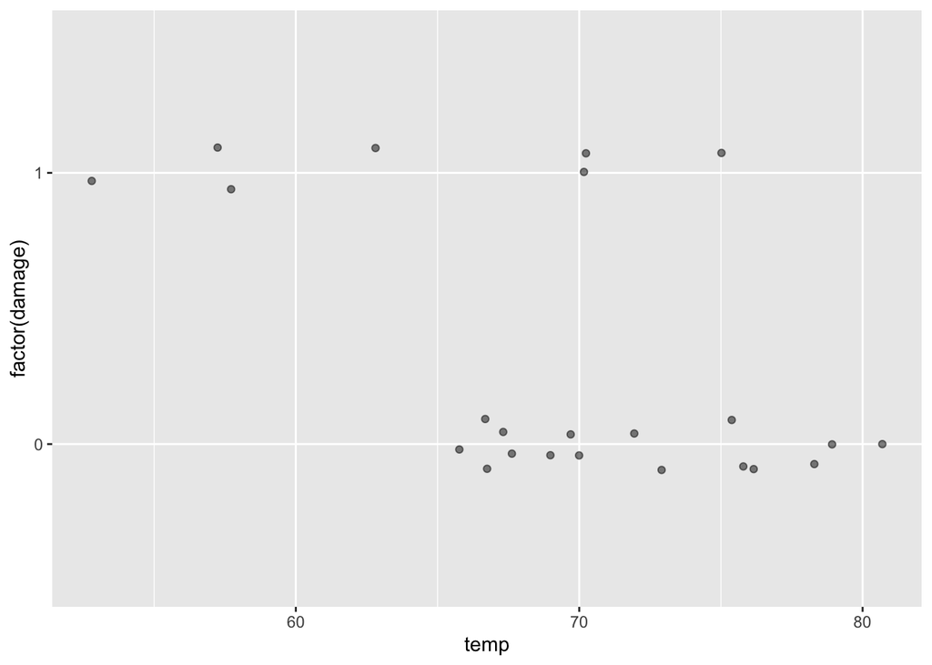

```r
orings |> ggplot(aes(x = temp, y = factor(damage))) +
  geom_jitter(height = 0.1, alpha = 0.5)
```

## Guess about statistical significance

# Non-traditional methods

We’ll use **`infer`**’s `fit()` function. Because the response is a two-level factor, `infer` fits a **logistic regression** via `glm()`. Permuting the response and refitting gives a null distribution for the coefficient on `temp`.

## Observed coefficients

```r
obs_fit <- orings |>
  mutate(damage = factor(damage)) |>
  specify(damage ~ temp) |>
  fit()
obs_fit
```

```
## # A tibble: 2 × 2
##   term      estimate
##   <chr>        <dbl>
## 1 intercept   15.0
## 2 temp        -0.232
```

## Randomization for Hypothesis Test

Under the null of no association, the `damage` labels are exchangeable, so `infer` shuffles them with `hypothesize(null = "independence")`, refits the logistic model, and records each coefficient 1,000 times.

```r
set.seed(2018)
null_fits <- orings |>
  mutate(damage = factor(damage)) |>
  specify(damage ~ temp) |>
  hypothesize(null = "independence") |>
  generate(reps = 1000, type = "permute") |>
  fit()
```

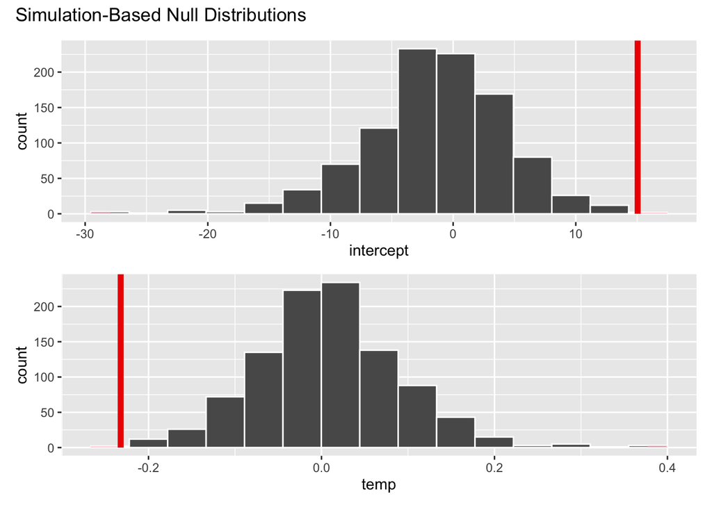

```r
visualize(null_fits) +
  shade_p_value(obs_stat = obs_fit, direction = "both")
```

### Calculate $p$-value

```r
get_p_value(null_fits, obs_stat = obs_fit, direction = "both")
```

```
## # A tibble: 2 × 2
##   term      p_value
##   <chr>       <dbl>
## 1 intercept   0.004
## 2 temp        0.004
```

The $p$-value for `temp` is small, so we reject the null hypothesis at the 5% level.

# Traditional methods

## Check conditions

Remember that in order to use the shortcut (formula-based, theoretical) approach, we need to check that some conditions are met.

1. *Linear relationship between linked response and predictor*: This condition is difficult to check without binning the data and computing the empirical logit function. The plot of the data and the fitted logistic curve can usually provide a good idea on the quality of the fit.

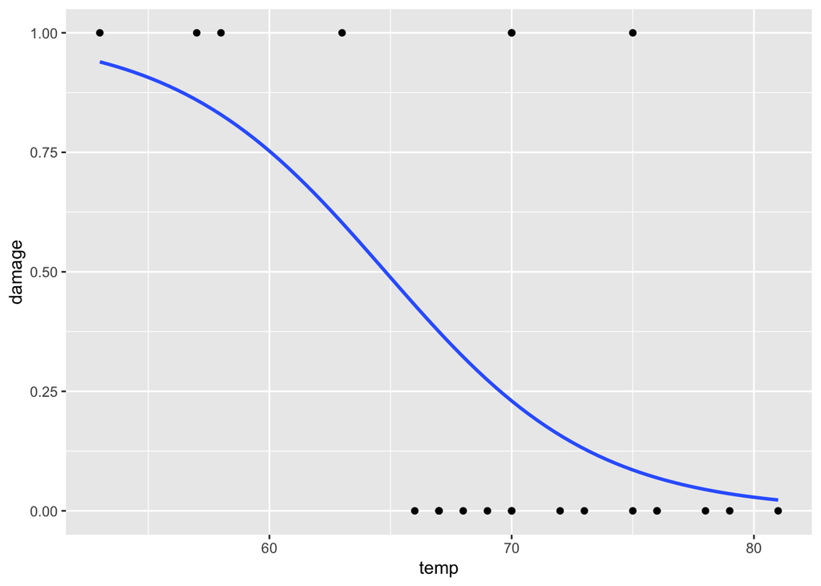

   ```r
   orings |> ggplot(aes(x = temp, y = damage)) +
     geom_point() +
     stat_smooth(method = "glm",
       method.args = list(family = "binomial"),
       se = FALSE)
   ```

   We have no clear reason to doubt the fit based on this plot.
2. *Independent observations*: The shuttle missions were selected at random here so the independent observations condition is met.

## Test statistic

We estimate the population coefficient $\beta_1$ with the sample coefficient $B_1$, a random variable that varies from sample to sample. If the conditions are met and assuming $H_0$ is true, we can standardize $B_1$ into a $Z$ statistic that follows a $N(0,1)$ distribution:

$$Z =\dfrac{ B_1 - 0}{ {SE}_1 } \sim N(0,
1)$$

## Observed test statistic

We use the `glm` function with `family = binomial` to fit the logistic curve, summarizing the output with `moderndive`’s `get_regression_table()`.

```r
oring_glm <- glm(damage ~ temp, data = orings, family = binomial)
get_regression_table(oring_glm)
```

```
## # A tibble: 2 × 7
##   term      estimate std_error statistic p_value lower_ci upper_ci
##   <chr>        <dbl>     <dbl>     <dbl>   <dbl>    <dbl>    <dbl>
## 1 intercept   15.0       7.38       2.04   0.041    3.33    34.3
## 2 temp        -0.232     0.108     -2.14   0.032   -0.515   -0.061
```

We see here that the observed coefficient on `temp` is around -0.232, corresponding to a $z$ statistic of about -2.14 and a $p$-value near 0.032. The negative sign corresponds to a negative relationship between temperature and failure, which is what we saw in the plot earlier.

# State conclusion

# Comparing results

The simulation-based (`infer::fit()` permutation) and theory-based (`glm()` + `get_regression_table()`) approaches agree that the coefficient on `temp` is statistically significant, both leading us to reject the null hypothesis.

Diez, David, Christopher Barr, and Mine Cetinkaya-Rundel. 2015. *OpenIntro Statistics, Third Edition*.